# Лабораторная 2

Кривенко Тимур Сергеевич **Б23-902

В нашем документе всего 3 листа, прочитаем каждый из них и сразу переименуем столбцы без имен:

```r
emissions_data <- as.data.frame(read_excel("Вариант27_Б23-902_Кривенко.xlsx", sheet = 1))
other_info <- as.data.frame(read_excel("Вариант27_Б23-902_Кривенко.xlsx", sheet = 2))
wind_rose <- as.data.frame(read_excel("Вариант27_Б23-902_Кривенко.xlsx", sheet = 3))
colnames(emissions_data)[1] <- "Дата"
colnames(wind_rose)[1] <- "Направление"
```

Посмотрим, какие у нас получились данные:

```r
head(emissions_data)
```

```
##         Дата Диоксид углерода    Фосген   Диоксин Диоксид серы Этиленоксид
## 1 2013-01-01         571.5746 0.4961748 0.3529872   0.02284646   0.7845525
## 2 2013-01-02         496.7492 0.5364990 0.2235081   0.09798894   0.7637295
## 3 2013-01-03         724.4791 0.4509075 0.2614492   0.03398173   0.7157002
## 4 2013-01-04         395.5879 0.5050256 0.2021678   0.05370828   0.7013607
## 5 2013-01-05         586.9553 0.5936020 0.2874349   0.03216028   0.7197597
## 6 2013-01-06         702.3838 0.5640631 0.3164935   0.07319815   0.7100773
```

```r
head(other_info)
```

```
##           Вещество Ед. измерения   ПДК Штраф, тыс.руб
## 1 Диоксид углерода        мг/м^3 7e+02             95
## 2           Фосген        мг/м^3 5e-01            345
## 3          Диоксин        пг/м^3 5e-01            250
## 4     Диоксид серы        мг/м^3 5e-02            145
## 5      Этиленоксид        мг/м^3 1e+00            270
##   Стоимость системы, тыс.руб. Стоимость обслуживания, тыс.руб.
## 1                        1040                              208
## 2                        8815                             1763
## 3                        5019                             1004
## 4                        3705                              741
## 5                        2464                              493
```

```r
head(wind_rose)
```

```
##     Направление Дней_в_году
## 1         Север          16
## 2 Северо-восток           9
## 3        Восток          18
## 4    Юго-восток          31
## 5            Юг          87
## 6     Юго-запад          80
```

1. Оценим совокупные затраты на установку **очистных сооружений**. Для этого возьмем сумму по сумму по 5 и 6 столбику из таблицы *other_info*. Также для пункта 8, рассчитаем затраты по веществам

```r
print(paste("Затраты на реализацию стратегии =", (sum(other_info[, 5]) + (sum(other_info[, 6]) * 5)) * 1000, "₽"))
```

```
## [1] "Затраты на реализацию стратегии = 42088000 ₽"
```

```r
capexes <- vector("numeric")
for(i in 1: 5){
  capexes[i] <- (other_info[i, 5] + other_info[i, 6] * 5) * 1000
}
print(capexes)
```

```
## [1]  2080000 17630000 10039000  7410000  4929000
```

2. Очистим данные от выбросов при помощи одностороннего критерия Граббса. Критерий Грабса считается наиболее мощным критерием для определения выбросов. Но все тесты они в целом валидны, только для случаев, когда распределение нормальное. В качестве аргументов используется параметры нормального распределения.

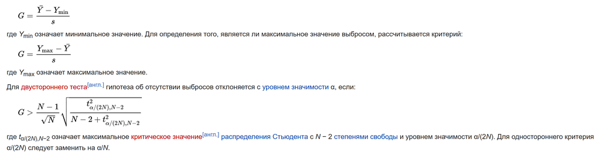

   Для начала рассчитаем критическое значение для всех выборок с уровнем значимости α = 0.05. Критическое значение будем использовать для всех выборок т.к. кол-во элементов одинаково.

```r
n <- nrow(emissions_data)
alpha <- 0.05

critical_student <- qt(1 - alpha/(n), n - 2)
critical_grubbs <- ((n - 1) / sqrt(n)) * sqrt(critical_student^2 / (n - 2 + critical_student^2))
print(paste("Критическое значение Граббса = ", critical_grubbs))
```

```
## [1] "Критическое значение Граббса =  4.18951231381659"
```

Теперь напишем две функции для расчета критерия.

```r
grubbs_max <- function(array) {
  array <- na.omit(array)
  max_el <- max(array)
  m <- mean(array)
  s <- sd(array)
  if (s == 0) return(NA)
  return((max_el - m) / s)
}

grubbs_min <- function(array) {
  array <- na.omit(array)
  min_el <- min(array)
  m <- mean(array)
  s <- sd(array)
  if (s == 0) return(NA)
  return((m - min_el) / s)
}
```

2.1 Диоксид углерода

Для начала нужно проверить распределение выборки на нормальность при помощи критерий Колмогорова-Смирнова, который показывает, насколько сильно отличаются два распределения.

```r
data_clean <- na.omit(emissions_data[[2]])
ks.test(data_clean, "pnorm", mean(data_clean), sd(data_clean))
```

```
##
##  Asymptotic one-sample Kolmogorov-Smirnov test
##
## data:  data_clean
## D = 0.016369, p-value = 0.2816
## alternative hypothesis: two-sided
```

```r
while (TRUE) {
  if (!is.na(grubbs_min(emissions_data[[3]])) && grubbs_min(emissions_data[[3]]) > critical_grubbs) {
    min_pos <- which.min(emissions_data[[3]])
    emissions_data[min_pos, 3] <- NA
  } else {
    break
  }
}

while (TRUE) {
  if (!is.na(grubbs_max(emissions_data[[3]])) && grubbs_max(emissions_data[[3]]) > critical_grubbs) {
    max_pos <- which.max(emissions_data[[3]])
    emissions_data[max_pos, 3] <- NA
  } else {
    break
  }
}

print(paste(length(emissions_data[[3]])))
```

```
## [1] "3653"
```

2.2 Фосген

Проверка распределения:

```r
data_clean <- na.omit(emissions_data[[3]])
ks.test(data_clean, "pnorm", mean(data_clean), sd(data_clean))
```

```
##
##  Asymptotic one-sample Kolmogorov-Smirnov test
##
## data:  data_clean
## D = 0.0071938, p-value = 0.9916
## alternative hypothesis: two-sided
```

Также нет оснований отвергать гипотезу о нормальном распределении. Аналогично удаляем выбросы:

```r
while (TRUE) {
  if (!is.na(grubbs_min(emissions_data[[3]])) && grubbs_min(emissions_data[[3]]) > critical_grubbs) {
    min_pos <- which.min(emissions_data[[3]])
    emissions_data[min_pos, 3] <- NA
  } else {
    break
  }
}

while (TRUE) {
  if (!is.na(grubbs_max(emissions_data[[3]])) && grubbs_max(emissions_data[[3]]) > critical_grubbs) {
    max_pos <- which.max(emissions_data[[3]])
    emissions_data[max_pos, 3] <- NA
  } else {
    break
  }
}


print(paste(length(emissions_data[[3]])))
```

```
## [1] "3653"
```

2.3 Диоксин

```r
data_clean <- na.omit(emissions_data[[4]])
ks.test(data_clean, "pnorm", mean(data_clean), sd(data_clean))
```

```
##
##  Asymptotic one-sample Kolmogorov-Smirnov test
##
## data:  data_clean
## D = 0.077394, p-value < 2.2e-16
## alternative hypothesis: two-sided
```

2.4 Диоксид серы

```r
data_clean <- na.omit(emissions_data[[5]])
ks.test(data_clean, "pnorm", mean(data_clean), sd(data_clean))
```

```
##
##  Asymptotic one-sample Kolmogorov-Smirnov test
##
## data:  data_clean
## D = 0.036012, p-value = 0.0001535
## alternative hypothesis: two-sided
```

2.5 Этиленоксид

```r
data_clean <- na.omit(emissions_data[[6]])
ks.test(data_clean, "pnorm", mean(data_clean), sd(data_clean))
```

```
##
##  Asymptotic one-sample Kolmogorov-Smirnov test
##
## data:  data_clean
## D = 0.15672, p-value < 2.2e-16
## alternative hypothesis: two-sided
```

В случае с Диоксином, Диоксидом серы и Этиленоксидом выборки не имеют нормального распределения. Будем также удалять по методу граббса, но уменьшать уровень значимости до 0.01 и относится к результатам с **опаской** Расчет критического значения Граббса с уровнем значимости 0.01

```r
n <- nrow(emissions_data)
alpha <- 0.01

critical_student <- qt(1 - alpha/(n), n - 2)
sus_critical_grubbs <- ((n - 1) / sqrt(n)) * sqrt(critical_student^2 / (n - 2 + critical_student^2))
print(paste("Критическое значение Граббса = ", sus_critical_grubbs))
```

```
## [1] "Критическое значение Граббса =  4.53959902698619"
```

Удаление из Диоксина

```r
while (TRUE) {
  if (!is.na(grubbs_min(emissions_data[[4]])) && grubbs_min(emissions_data[[4]]) > sus_critical_grubbs) {
    min_pos <- which.min(emissions_data[[4]])
    emissions_data[min_pos, 4] <- NA
  } else {
    break
  }
}

while (TRUE) {
  if (!is.na(grubbs_max(emissions_data[[4]])) && grubbs_max(emissions_data[[4]]) > sus_critical_grubbs) {
    max_pos <- which.max(emissions_data[[4]])
    emissions_data[max_pos, 4] <- NA
  } else {
    break
  }
}

print(paste(length(emissions_data[[4]])))
```

```
## [1] "3653"
```

Удаление из Диоксида серы

```r
while (TRUE) {
  if (!is.na(grubbs_min(emissions_data[[5]])) && grubbs_min(emissions_data[[5]]) > sus_critical_grubbs) {
    min_pos <- which.min(emissions_data[[5]])
    emissions_data[min_pos, 5] <- NA
  } else {
    break
  }
}

while (TRUE) {
  if (!is.na(grubbs_max(emissions_data[[5]])) && grubbs_max(emissions_data[[5]]) > sus_critical_grubbs) {
    max_pos <- which.max(emissions_data[[5]])
    emissions_data[max_pos, 5] <- NA
  } else {
    break
  }
}

print(paste(length(emissions_data[[5]])))
```

```
## [1] "3653"
```

Удаление из Этиленоксида

```r
while (TRUE) {
  if (!is.na(grubbs_min(emissions_data[[6]])) && grubbs_min(emissions_data[[6]]) > sus_critical_grubbs) {
    min_pos <- which.min(emissions_data[[6]])
    emissions_data[min_pos, 6] <- NA
  } else {
    break
  }
}

while (TRUE) {
  if (!is.na(grubbs_max(emissions_data[[6]])) && grubbs_max(emissions_data[[6]]) > sus_critical_grubbs) {
    max_pos <- which.max(emissions_data[[6]])
    emissions_data[max_pos, 6] <- NA
  } else {
    break
  }
}

print(paste(length(emissions_data[[6]])))
```

```
## [1] "3653"
```

3. Теперь оценим степень близости распределений концентраций выбросов к известным теоритическим законам распределения. Для сравнения будем использовать Нормальный, Гамма, Экспоненциальный, Вейбулла распределения. Будем использовать критерий Андерсона-Дарлинга.

```r
closest_dist <- data.frame(matrix(nrow=5, ncol=4))
names(closest_dist) <- c("Нормальное", "Гамма", "Экспоненциальное", "Вейбулла")
rownames(closest_dist) <- c("Диоксид углерода", "Фосген", "Диоксин", "Диоксид серы", "Этиленоксид")
for (i in 1:5){
  data_clean <- na.omit(emissions_data[[i + 1]])  # если данные в emissions_data с 2 по 6
  data_clean <- data_clean[is.finite(data_clean)]

  res_norm <- gofTest(data_clean, distribution = "norm", test = "ad", withInference = TRUE)
  res_gamma <- gofTest(data_clean, distribution = "gamma", test = "ad", withInference = TRUE)
  res_exp <- gofTest(data_clean, distribution = "exp", test = "ad", withInference = TRUE)
  res_weibull <- gofTest(data_clean, distribution = "weibull", test = "ad", withInference = TRUE)

  closest_dist[i, 1] <- round(res_norm$p.value, 3)
  closest_dist[i, 2] <- round(res_gamma$p.value, 3)
  closest_dist[i, 3] <- round(res_exp$p.value, 3)
  closest_dist[i, 4] <- round(res_weibull$p.value, 3)
}
kable(closest_dist, caption="Таблица 1. Близость к известным распределениям.")
```

Таблица 1. Близость к известным распределениям.

|  | Нормальное | Гамма | Экспоненциальное | Вейбулла |
| --- | --- | --- | --- | --- |
| Диоксид углерода | 0.001 | 0 | 0 | 0.718 |
| Фосген | 0.922 | 0 | 0 | 0.000 |
| Диоксин | 0.000 | 0 | 0 | 0.000 |
| Диоксид серы | 0.000 | 0 | 0 | 0.941 |
| Этиленоксид | 0.000 | 0 | 0 | 0.000 |

4.1 Теперь построим графики с отображением эмпирических и теоретических распределений и плотностей распределений для сравниваемых законов. Начнем с графиков распределения.

[figure not shown]

[figure not shown]

[figure not shown]

[figure not shown]

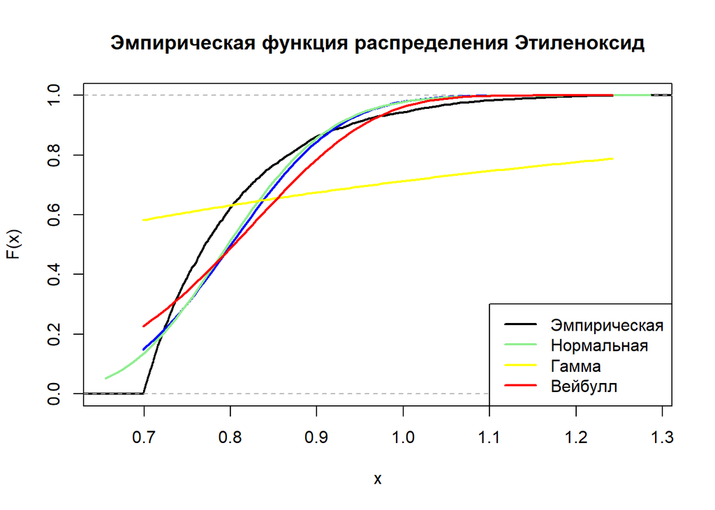

```r
for (i in 1:5){
  data <- emissions_data[[i+1]]

  # Очистка
  data <- data[is.finite(data)]
  data <- na.omit(data_clean)
  data <- data[data > 0]


  emp_cdf <- ecdf(data)
  plot(emp_cdf,
       main = paste("Эмпирическая функция распределения",
                    names(emissions_data)[i+1]),
       xlab = "x",
       ylab = "F(x)",
       lwd = 2)
  mean_val <- mean(data)
  sd_val <- sd(data)
  curve(pnorm(x, mean_val, sd_val),
      from = min(data),
      to = max(data),
      col = "blue", lwd = 2, add = TRUE)

  fit_gamma <- fitdistr(data, "gamma")
  curve(pgamma(x, shape=fit_gamma$estimate["shape"],
               rate=fit_gamma$estimate["rate"]),
                col="lightgreen", lwd=2, add=TRUE)

  lambda_exp <- 1 / mean(data)
  curve(pexp(x, rate = lambda_exp),
      from = min(data), to = max(data),
      col = "yellow", lwd = 2, add = TRUE)

  fit_weibull <- fitdist(data, "weibull")
  shape_w <- fit_weibull$estimate["shape"]
  scale_w <- fit_weibull$estimate["scale"]
  curve(pweibull(x, shape = shape_w, scale = scale_w),
      from = min(data), to = max(data),
      col = "red", lwd = 2, add = TRUE)

  legend("bottomright",
         legend=c("Эмпирическая", "Нормальная", "Гамма", "Вейбулл"),
         col=c("black", "lightgreen", "yellow", "red"), lwd=2)

}
```

4.2 Плотности распределений

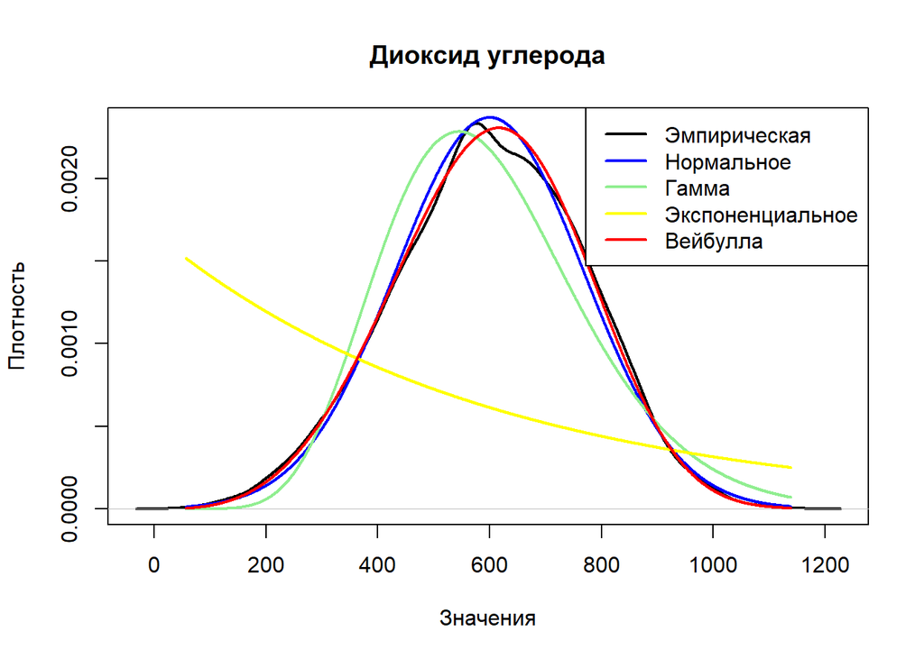

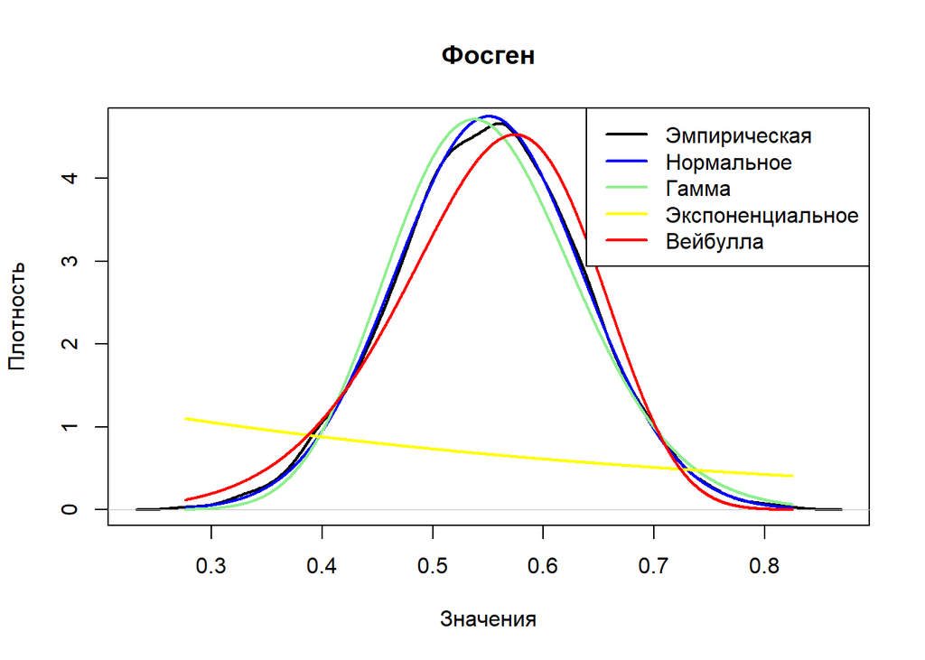

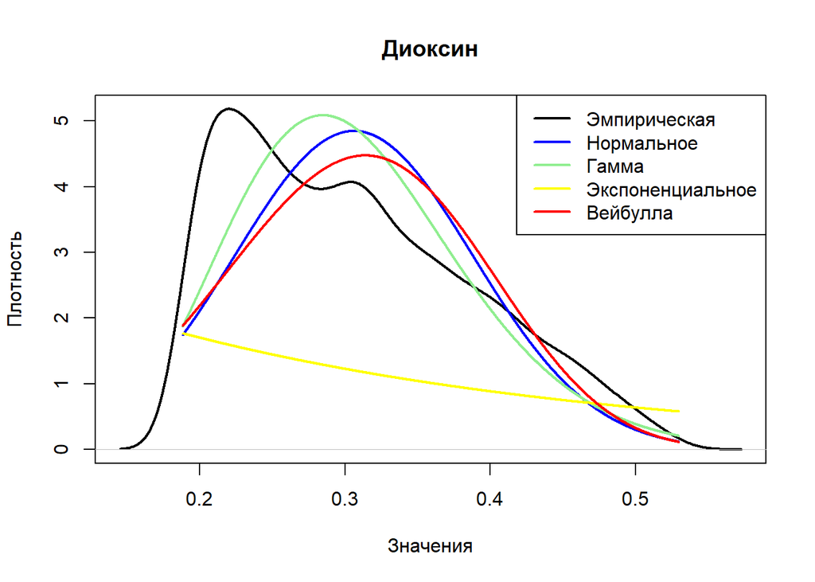

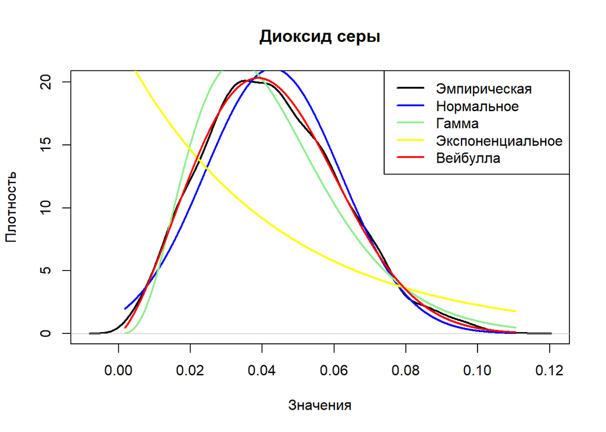

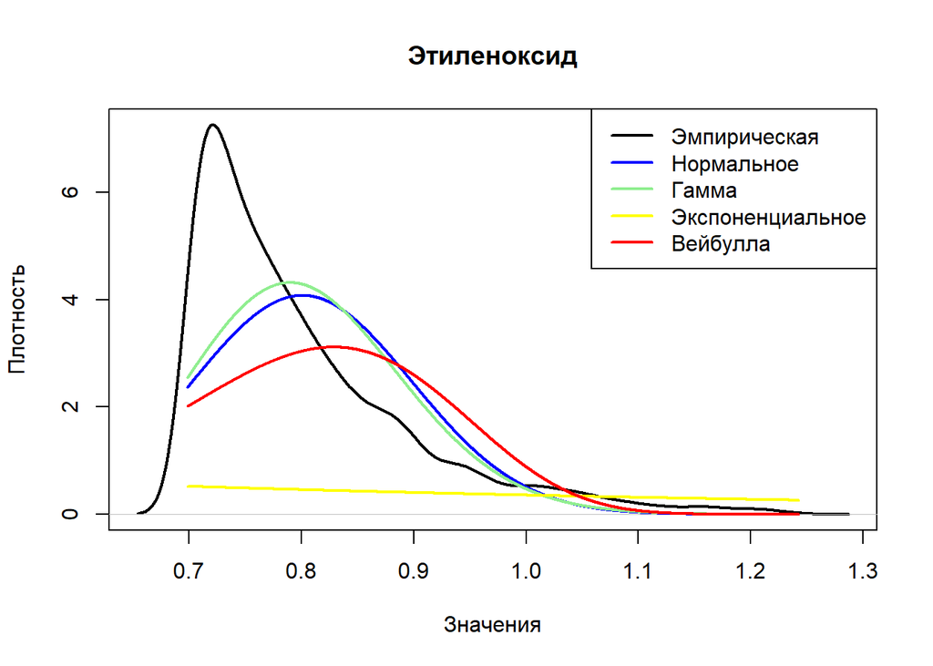

```r
graph_names <- c("Диоксид углерода", "Фосген", "Диоксин", "Диоксид серы", "Этиленоксид")
for(i in 1:5){
  data <- emissions_data[[i+1]]


  data <- data[is.finite(data)]

  data_length <- length(data)

  mean_val <- mean(data)
  sd_val <- sd(data)

  params_gamma <- fitdistr(data, "gamma")
  shape_gamma <- params_gamma$estimate["shape"]
  rate_gamma <- params_gamma$estimate["rate"]

  params_exp <- fitdistr(data, "exponential")
  rate_exp <- params_exp$estimate["rate"]

  params_weibull <- fitdistr(data, "weibull")
  shape_weibull <- params_weibull$estimate["shape"]
  scale_weibull <- params_weibull$estimate["scale"]

  x_vals <- seq(min(data), max(data), length.out = 3653)

  norm_emissions <- dnorm(x_vals, mean = mean_val, sd = sd_val)
  gamma_emissions <- dgamma(x_vals, shape = shape_gamma, rate = rate_gamma)
  ex_emissions <- dexp(x_vals, rate = rate_exp)
  weib_emissions <- dweibull(x_vals, shape = shape_weibull, scale = scale_weibull)

  plot(density(data), main = graph_names[i], xlab = "Значения", ylab = "Плотность", lwd = 2)
  lines(x_vals, norm_emissions, col = "blue", lwd = 2)
  lines(x_vals, gamma_emissions, col = "lightgreen", lwd = 2)
  lines(x_vals, ex_emissions, col = "yellow", lwd = 2)
  lines(x_vals, weib_emissions, col = "red", lwd = 2)
  legend("topright",
         legend = c("Эмпирическая", "Нормальное", "Гамма", "Экспоненциальное", "Вейбулла"),
         col = c("black", "blue", "lightgreen", "yellow", "red"), lwd = 2)
}
```

5.Построим гистограммы распределений

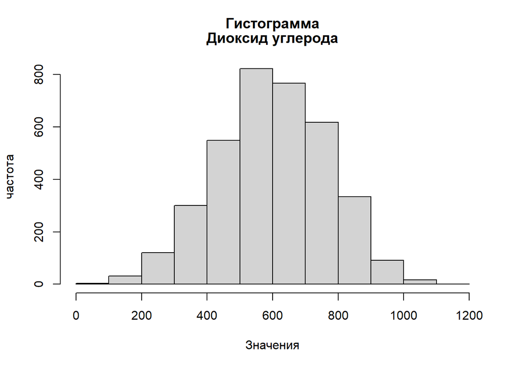

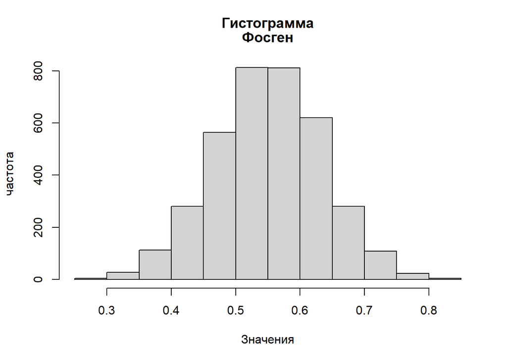

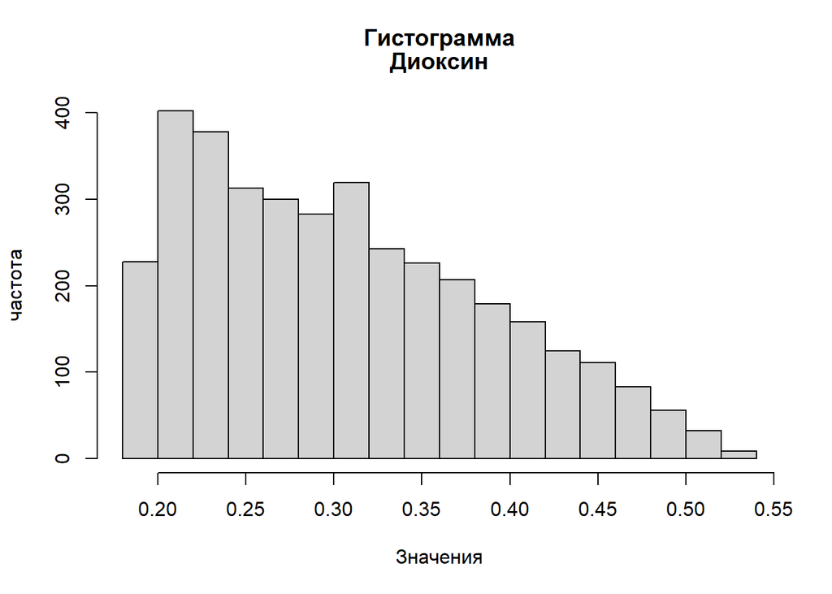

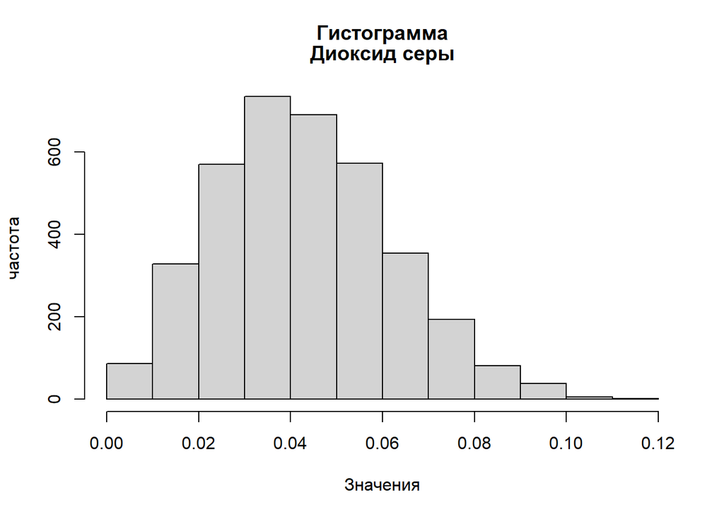

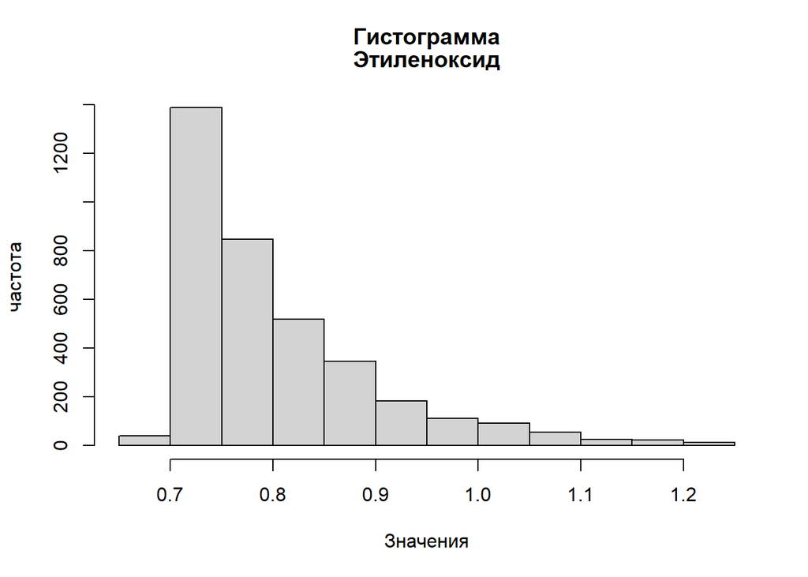

```r
for(i in 1:5){
  hist(emissions_data[[i + 1]],
       main = c("Гистограмма", graph_names[i]),
       xlab = "Значения",
       ylab = "частота",
       color = "grey")
}
```

6.1 Сформируем эмпирическую функцию распределения для Диоксина Воспользуемся определением: F(x)=nx/n, где nx - количество вариант строго меньших, чем x, а n - размер выборки.

```r
freq_diox <- table(sort(emissions_data$Диоксин))

emp_diox <- data.frame(matrix(nrow = length(freq_diox) + 1, ncol = 4))
names(emp_diox) <- c("", "ni","", "xi")
emp_diox[, 3] <- "если"
emp_diox[, 1] <- "F(x) = "
emp_diox[1, 2] <- 0
emp_diox[1, 4] <- paste("x <= ", names(freq_diox)[2])
diox_n <- 0
for(i in 1:length(freq_diox)){
  diox_n <- diox_n + as.numeric(freq_diox[i])
  var_sum_diox <- diox_n / length(freq_diox)
  emp_diox[i + 1, 2] <- var_sum_diox
  emp_diox[i + 1, 3] <- "если"
  emp_diox[i + 1, 4] <- paste(names(freq_diox)[i], "< x <= ", names(freq_diox)[i+1])
}
emp_diox[length(freq_diox)+1, 2] <- 1
emp_diox[length(freq_diox)+1, 4] <- paste("x > ", max(emissions_data$Диоксин))

head(emp_diox)
```

```
##                     ni                                               xi
## 1 F(x) =  0.0000000000 если                     x <=  0.188208145350462
## 2 F(x) =  0.0002738226 если 0.188194975404312 < x <=  0.188208145350462
## 3 F(x) =  0.0005476451 если 0.188208145350462 < x <=  0.188289750284796
## 4 F(x) =  0.0008214677 если 0.188289750284796 < x <=  0.188318365844708
## 5 F(x) =  0.0010952903 если 0.188318365844708 < x <=  0.188346040148721
## 6 F(x) =  0.0013691128 если 0.188346040148721 < x <=  0.188392427043864
```

```r
tail(emp_diox)
```

```
##                     ni                                               xi
## 3648 F(x) =  0.9986309 если 0.523184327771209 < x <=  0.523816525368395
## 3649 F(x) =  0.9989047 если 0.523816525368395 < x <=  0.526282139080543
## 3650 F(x) =  0.9991785 если 0.526282139080543 < x <=  0.527136716027388
## 3651 F(x) =  0.9994524 если 0.527136716027388 < x <=  0.528065711473645
## 3652 F(x) =  0.9997262 если 0.528065711473645 < x <=  0.529500407986509
## 3653 F(x) =  1.0000000 если                                     x >  NA
```

6.2 Сформируем эмпирическую функцию распределения для Этиленоксида

```r
freq_etil <- table(sort(emissions_data$Этиленоксид))

emp_etil <- data.frame(matrix(nrow = length(freq_etil) + 1, ncol = 4))
names(emp_etil) <- c("", "ni","", "xi")
emp_etil[, 3] <- "если"
emp_etil[, 1] <- "F(x) = "
emp_etil[1, 2] <- 0
emp_etil[1, 4] <- paste("x <= ", names(freq_etil)[2])
etil_n <- 0
for(i in 1:length(freq_etil)){
  etil_n <- etil_n + as.numeric(freq_etil[i])
  var_sum_etil <- etil_n / length(freq_etil)
  emp_etil[i + 1, 2] <- var_sum_etil
  emp_etil[i + 1, 3] <- "если"
  emp_etil[i + 1, 4] <- paste(names(freq_etil)[i], "< x <= ", names(freq_etil)[i+1])
}
emp_etil[length(freq_etil)+1, 2] <- 1
emp_etil[length(freq_etil)+1, 4] <- paste("x > ", max(emissions_data$Этиленоксид))

head(emp_etil)
```

```
##                     ni                                               xi
## 1 F(x) =  0.0000000000 если                      x <=  0.69884386741094
## 2 F(x) =  0.0002748008 если  0.698774090178946 < x <=  0.69884386741094
## 3 F(x) =  0.0005496015 если  0.69884386741094 < x <=  0.698849302308524
## 4 F(x) =  0.0008244023 если 0.698849302308524 < x <=  0.698851136132476
## 5 F(x) =  0.0010992031 если 0.698851136132476 < x <=  0.698932211468587
## 6 F(x) =  0.0013740038 если 0.698932211468587 < x <=  0.698990101155398
```

```r
tail(emp_etil)
```

```
##                     ni                                             xi
## 3635 F(x) =  0.9986260 если 1.21589452481095 < x <=  1.21684615742997
## 3636 F(x) =  0.9989008 если 1.21684615742997 < x <=  1.21689772511302
## 3637 F(x) =  0.9991756 если 1.21689772511302 < x <=  1.22733669098035
## 3638 F(x) =  0.9994504 если 1.22733669098035 < x <=  1.23176327353634
## 3639 F(x) =  0.9997252 если 1.23176327353634 < x <=  1.24232706564259
## 3640 F(x) =  1.0000000 если                                   x >  NA
```

```r
fine_probabilities <- vector("numeric")
wc_probability <- data.frame(matrix(nrow=5, ncol=4))
names(wc_probability) <- c("","","","")
for (i in 1: 5){
  wc_probability[i, 1] <- "P(X*z < e) ="
  wc_probability[i, 3] <- "для"

}

#Диоксид углерода
fit <- fitdist(emissions_data[[2]], "weibull")
dc_shape <- fit$estimate["shape"]
dc_scale <- fit$estimate["scale"]
dc_prob <- pweibull(700/0.9, shape=dc_shape, scale=dc_scale, lower.tail = FALSE)
wc_probability[1, 2] <- dc_prob
wc_probability[1, 4] <- names(emissions_data)[2]
fine_probabilities[1] <- dc_prob

#Фосген
f_m <- mean(emissions_data[[3]], na.rm = TRUE)
f_sd <- sd(emissions_data[[3]], na.rm = TRUE)
f_prob <- pnorm(0.5/0/9, mean=f_m, sd = f_sd, lower.tail = FALSE)
wc_probability[2, 2] <- f_prob
wc_probability[2, 4] <- names(emissions_data)[3]
fine_probabilities[2] <- f_prob

#Диоксин
d_emp   <- ecdf(emissions_data[[4]])
print(d_emp)
```

```
## function (v)
## .approxfun(x, y, v, method, yleft, yright, f, na.rm)
## <bytecode: 0x0000029ff23b3a00>
## <environment: 0x0000029ff2c6a890>
## attr(,"class")
## [1] "ecdf"     "stepfun"  "function"
## attr(,"call")
## ecdf(emissions_data[[4]])
```

```r
d_prob <- 1 - d_emp(0.5/0.9)      # P(X > q)
wc_probability[3, 2] <- d_prob
wc_probability[3, 4] <- names(emissions_data)[4]
fine_probabilities[3] <- f_prob

#Диоксид серы
fit <- fitdist(emissions_data[[5]], "weibull")
ds_shape <- fit$estimate["shape"]
ds_scale <- fit$estimate["scale"]
ds_prob <- pweibull(0.05/0.9, shape=ds_shape, scale=ds_scale, lower.tail = FALSE)
wc_probability[4, 2] <- ds_prob
wc_probability[4, 4] <- names(emissions_data)[5]
fine_probabilities[4] <- ds_prob

# Этиленоксид
e_emp   <- ecdf(emissions_data[[6]])
print(e_emp)
```

```
## function (v)
## .approxfun(x, y, v, method, yleft, yright, f, na.rm)
## <bytecode: 0x0000029ff23b3a00>
## <environment: 0x0000029ff6924500>
## attr(,"class")
## [1] "ecdf"     "stepfun"  "function"
## attr(,"call")
## ecdf(emissions_data[[6]])
```

```r
e_prob <- 1 - e_emp(1/0.9)
wc_probability[5, 2] <- e_prob
wc_probability[5, 4] <- names(emissions_data)[6]
fine_probabilities[5] <- e_prob

kable(wc_probability)
```

| P(X*z < e) = | 0.1475857 | для | Диоксид углерода |
| --- | --- | --- | --- |
| P(X*z < e) = | 0.0000000 | для | Фосген |
| P(X*z < e) = | 0.0000000 | для | Диоксин |
| P(X*z < e) = | 0.2472939 | для | Диоксид серы |
| P(X*z < e) = | 0.0151140 | для | Этиленоксид |

```r
fines <- c(95, 345, 250, 145, 270)
summ_fines <- 0
for(i in 1:5){
  summ_fines <- summ_fines + fines[i] * (365 * 5 * fine_probabilities[i])
}
paste("Сумма штрафов за 5 лет при условии худшего ветра = ", round(summ_fines * 1000), "₽")
```

```
## [1] "Сумма штрафов за 5 лет при условии худшего ветра =  98475263 ₽"
```

```r
ind_fines <- vector("numeric")
for (i in 1:5){
  print(paste("Штраф за 5 лет для ", names(emissions_data)[i+1], "=", round(fines[i] * (365 * 5 * fine_probabilities[i])) * 1000, "₽"))
  ind_fines[i] <- round(fines[i] * (365 * 5 * fine_probabilities[i])) * 1000
}
```

```
## [1] "Штраф за 5 лет для  Диоксид углерода = 25588000 ₽"
## [1] "Штраф за 5 лет для  Фосген = 0 ₽"
## [1] "Штраф за 5 лет для  Диоксин = 0 ₽"
## [1] "Штраф за 5 лет для  Диоксид серы = 65440000 ₽"
## [1] "Штраф за 5 лет для  Этиленоксид = 7447000 ₽"
```

9. Отсеим такие вещества, для которых совокупный штраф заведомо меньше капитальных затрат.

```r
for (i in 1:5){
  if (capexes[i] >= ind_fines[i]){
      print(paste("Стоимость установки и обслуживания больше, чем сумма штрафов в худшем случае для",
            names(emissions_data)[i + 1]))
  }
  else{
    print(paste("Сумма штрафов в худшем случае больше, чем капитальные затраты на установку очишающего оборудования    для",names(emissions_data)[i + 1]))
  }
}
```

```
## [1] "Сумма штрафов в худшем случае больше, чем капитальные затраты на установку очишающего оборудования    для Диоксид углерода"
## [1] "Стоимость установки и обслуживания больше, чем сумма штрафов в худшем случае для Фосген"
## [1] "Стоимость установки и обслуживания больше, чем сумма штрафов в худшем случае для Диоксин"
## [1] "Сумма штрафов в худшем случае больше, чем капитальные затраты на установку очишающего оборудования    для Диоксид серы"
## [1] "Сумма штрафов в худшем случае больше, чем капитальные затраты на установку очишающего оборудования    для Этиленоксид"
```

10-12. Для оставшихся веществ — составим формулу полной вероятности получения штрафа при условии разной интенсивности разных направлений ветров

```r
result <- data.frame(matrix(nrow = 3, ncol = 5))
names(result) <- c("Вещество", "Вероятность", "CAPEX", "Ожидаемый штраф за 5 лет", "Рекомендация")
result[1, 1] <- "Диоксид углерода"
result[2, 1] <- "Диоксид серы"
result[3, 1] <- "Этиленоксид"

substances <- c("Диоксид углерода", "Диоксид серы", "Этиленоксид")
fines <- c(95, 145, 270)
thresholds <- c(700, 0.05, 1)

wind_data <- data.frame(
  direction = c("Север", "Северо-восток", "Восток", "Юго-восток",
                "Юг", "Юго-запад", "Запад", "Северо-запад"),
  days = c(16, 9, 18, 31, 87, 80, 105, 19),
  efficiency = c(0, 0.25, 0.5, 0.9, 0.75, 0.4, 0.1, 0)
)


fit_dc <- fitdist(emissions_data[[2]], "weibull")
dc_shape <- fit_dc$estimate["shape"]
dc_scale <- fit_dc$estimate["scale"]

fit_ds <- fitdist(emissions_data[[5]], "weibull")
ds_shape <- fit_ds$estimate["shape"]
ds_scale <- fit_ds$estimate["scale"]

weibull_shapes <- c(dc_shape, ds_shape)
weibull_scales <- c(dc_scale, ds_scale)

wind_probs <- wind_data$days / 365
eff <- wind_data$efficiency

prob_weibull <- function(threshold, shape, scale, eff) {
  if (is.na(eff) || eff == 0) return(0)
  # P(X > threshold/eff) = 1 - F_Weibull(threshold/eff)
  return (1 - pweibull(threshold / eff, shape = shape, scale = scale))
}

prob_ecdf <- function(sample, threshold, eff) {
  if (is.na(eff) || eff == 0) return(0)
  emp <- ecdf(sample)
  return (1 - emp(threshold / eff))
}


full_prob_fines <- numeric(3)
expected_fines_5_years <- numeric(3)

for (i in 1:3) {

  sample <- emissions_data[[i + 2]]
  thr <- thresholds[i]
  fine <- fines[i]

  if (i <= 2) {
    shape <- weibull_shapes[i]
    scale <- weibull_scales[i]

    prob_per_wind <- sapply(eff, function(e) prob_weibull(thr, shape, scale, e))

  } else {
    prob_per_wind <- sapply(eff, function(e) prob_ecdf(sample, thr, e))
  }

  P_day <- sum(wind_probs * prob_per_wind, na.rm = TRUE)

  full_prob_fines[i] <- P_day
  result[i, 2] <- P_day

  expected_fines_5_years[i] <- P_day * 365 * 5 * fine * 1000
  result[i, 4] <- round(expected_fines_5_years[i])
}

capexes_cur <- capexes[c(1, 4, 5)]
result$CAPEX <- capexes_cur

for (i in 1:3) {
  if (is.na(expected_fines_5_years[i]) || is.na(capexes_cur[i])) {
    result[i, 5] <- NA
  } else if (expected_fines_5_years[i] < capexes_cur[i]) {
    result[i, 5] <- "Выгоднее платить штрафы"
  } else {
    result[i, 5] <- "Выгоднее установить очистное оборудование"
  }
}

kable(result, format = "html",
      table.attr = "style='border-collapse: separate; border-spacing: 20px 0px;'")
```

[output not shown]

**Ссылки:**

[t-критерий Стьюдента](https://ru.wikipedia.org/wiki/T-%D0%BA%D1%80%D0%B8%D1%82%D0%B5%D1%80%D0%B8%D0%B9_%D0%A1%D1%82%D1%8C%D1%8E%D0%B4%D0%B5%D0%BD%D1%82%D0%B0)

[ГОСТ Р 8.736-2011](https://www.expertnk.ru/docs/libs/gost-r-8.736-2011.pdf)

[Википедия. Критерий Граббса](https://ru.wikipedia.org/wiki/%D0%9A%D1%80%D0%B8%D1%82%D0%B5%D1%80%D0%B8%D0%B9_%D0%93%D1%80%D0%B0%D0%B1%D0%B1%D1%81%D0%B0)

[GeeksForGeeks. How to Perform Grubbs’ Test in R](https://www.geeksforgeeks.org/r-language/how-to-perform-grubbs-test-in-r/)

[MathProfi](https://mathprofi.com/knigi_i_kursy/files/matstat_demo.pdf)